# Resolviendo conflictos en Git y GitHub

## Agradecimientos

- Este documento se basa en “Happy Git with R” de Jenny Bryan, los STAT 545 TAs, Jim Hester

https://happygitwithr.com

## Git es Amor!

[figure not shown]

## Usando git de forma segura

- Usando commit podemos evitar problemas
- Cada commit es un pin de seguridad en una escalada
- Debemos hacer commit LOCAL continuamente
- LOCAL quiere decir sin PUSH

[figure not shown]

```bash
git commit -m "Mensaje que diga que hice"
```

## Commit al infinito

- Hacer commit LOCAL es muy bueno pero puede dejar nuestra historia un poco intensa

[figure not shown]

## Commit al infinito

- Para eso existe amend
- no-edit va a dejar el mensaje original del commit

```bash
git commit -m "Mensaje que diga que hice"
git commit --amend --no-edit
```

- Cuando hayamos terminado de trabajar podemos cambiar el mensaje y dejar algo más completo

```bash
git commit --amend --m "ahora que ya terminé puedo dejar algo más completo"
git push
```

## Viajando en el tiempo

- Estamos trabajando y nos equivocamos y ya nada sirve
- Podemos volver al último commit donde todo funcionaba!

[figure not shown]

```bash
git reset --hard
```

## Reescribiendo la historia

```bash
git reset --hard HEAD
git pull
```

1. Si estamos super seguros que nadie de nuestro equipo hizo pull de nuestro error, entonces podemos hacer un push force

```bash
git push --force
```

## Reescribiendo la historia

- Repetimos: De verdad no hay que hacer force

[figure not shown]

## Rechazo de PUSH

- Un problema común es que intentemos hacer PUSH a nuestro repositorio central y que se rechacen nuestros cambios

```bash
$ git push
To https://github.com/YOU/REPO.git
 ! [rejected]        master -> master (fetch first)
error: failed to push some refs to 'https://github.com/YOU/REPO.git'
hint: Updates were rejected because the remote contains work that you do
hint: not have locally. This is usually caused by another repository pushing
hint: to the same ref. You may want to first integrate the remote changes
hint: (e.g., 'git pull ...') before pushing again.
hint: See the 'Note about fast-forwards' in 'git push --help' for details.
```

-Esto quiere decir que el repositorio central y lo que tenemos local han divergido.

## Rechazo de PUSH

-Solución: hacer PULL a local y lidiar con los conflictos

-Cómo evitar que estemos pasando por este tipo de situaciones:

1. No trabajar offline demasiado tiempo y hacer commit y PUSH seguido.
2. Hacer PULL de forma continua para evitar divergir. Así si algo divergió el merge será menos doloroso.
3. Trabajo en equipo, comunicación en equipo. Si sabemos qué hacen los demás es más fácil evitar conflictos.
4. Uso de branches, organizar el progreso de nuestro trabajo en equipo en branches hará menos doloroso hacer integración con otras versiones.

## Rechazo de PUSH > Hagamos PULL

- Inevitable: nos rechazan un PUSH así que debemos hacer PULL
- Nuestra historia local:

A–B–C

A–B– Cambios sin commit

- La historia en el repositorio central:

A–B–D

- Lo que queremos:

[figure not shown]

## PULL con cambios locales sin commit

-Escenario 1: PULL feliz

```bash
git pull
```

## PULL con conflictos

- Si hay sobrelape entre lo que hicimos local y el repo central pull va a fallar

```bash
$ git pull
remote: Enumerating objects: 5, done.
remote: Counting objects: 100% (5/5), done.
remote: Compressing objects: 100% (2/2), done.
remote: Total 3 (delta 1), reused 1 (delta 0), pack-reused 0
Unpacking objects: 100% (3/3), done.
From github.com:jennybc/ethel
   db046b4..2d33a6f  master     -> origin/master
Updating db046b4..2d33a6f
error: Your local changes to the following files would be
overwritten by merge:
        foo.R
Please commit your changes or stash them before you merge.
Aborting
```

- Quién me dice cuál es el problema?

## Solución con git stash

- stash nos permite guardar los cambios locales que no pasamos a commit en un universo medio paralelo

```bash
$ git stash save
Saved working directory and index state WIP on master: db046b4
Merge branch 'master'of github.com:jennybc/ethel

$ git pull
Updating db046b4..2d33a6f
Fast-forward
 foo.R | 2 +-
 1 file changed, 1 insertion(+), 1 deletion(-)

$ git stash pop
Auto-merging foo.R
On branch master
Your branch is up-to-date with 'origin/master'.

Changes not staged for commit:
  (use "git add <file>..." to update what will be committed)
  (use "git checkout -- <file>..." to discard changes
  in working directory)

        modified:   foo.R

no changes added to commit
```

## Cuando git stash no trae la felicidad

```bash
git stash pop
Auto-merging foo.R
CONFLICT (content): Merge conflict in foo.R
```

## Merge conflics

- A veces, no tan a veces también, las cosas no salen bien a la primera
- Merging (Fusionar) es una de esas cosas
- Primera regla: NO ENTRAR EN PANICO!!!
- Revisen el status del repositorio. Qué archivo tiene conflicto?

## Merge conflics

- Abran ese archivo y busquen los problemas de merge. Es fácil, se ven así:

```r
<<<<<<< HEAD:index.html
<div id="footer">contact : email.support@github.com</div>
=======
<div id="footer">
 please contact us at support@github.com
</div>
>>>>>>> issue-5:index.html
```

- Editen esa sección, dejen una versión final.

## Regresando a git stash

- Ya tenemos la versión final de nuestro archivo conflictivo
- Ahora a limpiar un poco el desastre

```bash
$ git reset
$ git reset --mixed
Unstaged changes after reset:
M       foo.R
```

- git reset (default: mixed) nos va a regresar al “commit” anterior.
- PELIGRO: la opción hard de git reset incluso borra todo lo que pasó después del commit. Esto es como rm -f, así que con cuidado!

## Regresando a git stash

- Por último, debemos dejar el stash que estábamos haciendo

```bash
$ git stash drop
Dropped refs/stash@{0} (7928db50288e9b4d934803b6b451a000fd7242ed)
```

- Ya quedó todo listo para continuar

## Qué hacemos si si hicimos commit y PULL no funciona?

- PULL, fetch/merge

-El mejor escenario es que el merge es fácil por que no hay conflictos

```bash
$ git pull
<Se habre un editor de texto para que podamos añadir
un mensaje al Merge>
Merge made by the 'recursive' strategy.
 README.md | 4 ++--
 1 file changed, 2 insertions(+), 2 deletions(-)
```

## Qué hacemos si si hicimos commit y PULL no funciona?

- El escenario donde falla el merge

```bash
$ git pull
Auto-merging foo.R
CONFLICT (content): Merge conflict in foo.R
Automatic merge failed; fix conflicts and then commit the result.
```

- Arreglamos todo como la vez pasada, eligiendo en el archivo la versión que nos gusta y cuando estemos listos add y commit

```bash
$ git add foo.R
$ git commit
```

## PULL con rebase

- Pull combinado con su opción rebase hace una historia más limpia.
- Nos evitamos añadir otro commit consecuencia del merge
- Es tentador pero peligroso por que los cambios locales se aplicarán sobre los remotos

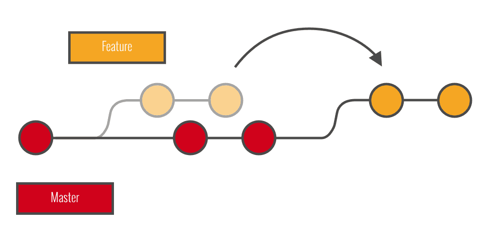

https://www.blog.duomly.com/

## PULL con rebase

```bash
$ git pull --rebase
First, rewinding head to replay your work on top of it...
Applying: Take max
```

- El problema: vamos a acarrear conflictos de merge en el futuro y nuestra historia se reescribe un poco

```bash
$ git rebase --abort
```

## Probemos nosotres!

- Vayan a GitHub y creen en repositorio “toxico”
- Creen un README
- Clonen este repositorio a sus computadoras
- Editen el README en su computadora
- Ahora editen el READM en el GitHub
- Traten de hacer pull, qué pasó?
- Cómo lo arreglamos?

## Todo es práctica

Y si nada funciona pues volvemos a instalar el repo

[figure not shown]